# Kruskal (2) (1)

## **Algorithme de Prim et de Kruskal pour la détermination d'arbres couvrants de poids minimal**

### **Eleve : Anty KOFFI**

#### Introduction

Suivant qu'on soit dans l'algorithme de Prim ou de Kruskal ces implémentations different. En effet, les structures de données du type dictionnaire permettent de modeliser plus facilement le problème de Prim. Malheuresement, il en resulte que plus la taille du graphe augmente, plus il est difficile d'aller chercher les données "en profondeur". Et donc, plus le temps de calcul augmente.

**1- Algorithme de PRIM**

- **Chargement du graphe dans le cas de Prim**

```python
import pandas as pd
data = pd.read_csv("a280.tsp.txt", sep=r"[ ]{1,}", engine='python')
X, Y = data["COORD"].values, data["SECTION"].values
coordonne = {}
for i in range(len(X)):
    coordonne[i + 1] = {X[i]: Y[i]}
```

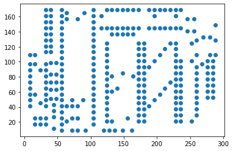

```python
from matplotlib import pyplot as plt

X = []
Y = []

for H_info, dictionnaire in coordonne.items() :
    for x,y in dictionnaire.items():
        X.append(x)
        Y.append(y)

plt.scatter(X,Y)
```

- **Determination de la liste des aretes par implementation de la distance euclidienne pour le cas de Prim**

```python
import math

def euclidean_distance(coordonne):
    """
    :param coordonne: l'ensemble des coordonnees des points a notre disposition

    :return: Distance euclidienne entre les sommets du graphe

    Le graphe etant Hamiltonien, tout les sommets sont adjacents deux à deux. Les sommets du graphe sont représentés
    par les clés,valeurs(x,y) d'un dictionnaire imbriqué au sommet considéré. Ce sommet représente la clé du
    dictionnaire.

    """
    k, v, abscice, ordonne = 0, 0, 0, 0
    point = []
    arete = {}
    distance = 0
    for sommet, value in coordonne.items():
        k = sommet
        v = value
        point.append(k)
        arete[k] = {}
        for v1, v2 in v.items():
            x = v1
            y = v2
        for s_prim, b in coordonne.items():
            if s_prim != k:
                for x_prim, y_prim in b.items():
                    distance = (math.sqrt(((x - x_prim) ** 2) + ((y - y_prim) ** 2)))
                if k not in arete:
                    arete[k] = {}
                arete[k].update({s_prim: distance})
                distance = 0
    return arete, point
```

- **L'algorithme**

```python
import numpy as np
def prim(distance, sommet, x0):
    """
    :param distance: Type dictionnaire. C'est le graphe avec les sommets ainsi que les aretes
    :param sommet: Type liste. liste de touts les sommet
    :param x0: Type int. C'est le sommet permettant de demarrer l'algorithme
    :return: la liste des arcs ainsi que leur valuation et l'arborescence du graphe
    """
    # Initialisation

    T = []
    sommet_T = [x0]
    n = len(sommet)
    pred_marqueur = {}
    pred = {}

    # Iteration k

    for k in range(n - 1):

        min_edge = float('Inf')
        minimums_by_edge = {}
        for x in sommet_T:

            liste_sommet_atteignable = [y for y in list(distance[x].keys()) if y not in sommet_T]
            for y in liste_sommet_atteignable:
                if distance[x][y] < min_edge:
                    min_edge = distance[x][y]
                    S = y
                    pred_marqueur[S] = {x: min_edge}
            minimums_by_edge[S] = min_edge

        next_edge = min(list(minimums_by_edge.values()))
        T.append(next_edge)
        ind_val_arc = np.argmin(list(minimums_by_edge.values()))
        next_sommet = list(minimums_by_edge.keys())[ind_val_arc]
        sommet_T.append(next_sommet)
        pred[next_sommet] = pred_marqueur[next_sommet]
        # print(sommet_T)

    return T, sommet_T, pred
```

- **Mini graph test**

```python
distance, sommet = euclidean_distance(coordonne) # Chargement des sommets et des distances
# On va faire un test sur un petit graphe :

graph = {
    1: {2: 2, 3: 3, 4: 3},
    3: {1: 3, 4: 5, 2: 4, 5: 1, 6: 6},
    4: {1: 3, 3: 5, 6: 7},
    2: {1: 2, 3: 4, 5: 3},
    5: {2: 3, 3: 1, 6: 8},
    6: {3: 6, 4: 7, 5: 8, 7: 9},
    7: {6: 9}
}

S = [1, 2, 3, 4, 5, 6, 7]

t, sommet_T,arborescence_graph = prim(graph, S, 1)
print("L'arborescence du graphe se presente alors comme suit : \n")
print(arborescence_graph)
```

```
L'arborescence du graphe se presente alors comme suit :

{2: {1: 2}, 3: {1: 3}, 5: {3: 1}, 4: {1: 3}, 6: {3: 6}, 7: {6: 9}}
```

- **Test sur le graphe de 280 sommets**

```python
import time
t0 = time.time()
t, sommet_T, arborescence_graph = prim(distance, sommet, 2)
t1 = time.time() - t0
print("Temps mis : "+str(t1)+"\n")
print("L'arborescence du graphe se presente alors comme suit : \n")
print(arborescence_graph)
```

```
Temps mis : 16.41117548942566

L'arborescence du graphe se presente alors comme suit :

{280: {2: 8.94427190999916}, 3: {280: 10.0}, 279: {3: 10.770329614269007}, 278: {279: 8.94427190999916}, 4: {279: 12.649110640673518}, 277: {4: 10.0}, 276: {277: 10.770329614269007}, 275: {276: 8.0}, 274: {275: 8.0}, 273: {274: 8.0}, 272: {273: 8.0}, 271: {272: 8.0}, 16: {271: 8.0}, 6: {276: 15.6204…
```

**2-Kruskal**

- Vu que le type de structure de données different, l'implementation des calculs des aretes egalement

```python
import math

def euclidean_distance_kruskal(coordonne):
    """
    :param coordonne: l'ensemble des coordonnees des points a notre disposition

    :return: Distance euclidienne entre les sommets du graphe

    Le graphe etant Hamiltonien, tout les sommets sont adjacents deux à deux. Les sommets du graphe sont représentés
    par les clés,valeurs(x,y) d'un dictionnaire imbriqué au sommet considéré. Ce sommet représente la clé du
    dictionnaire.

    """
    point = []
    arete = []
    distance = 0
    for i in range(0,len(coordonne)):
        point.append(coordonne[i][0])
        for j in range(i+1,len(coordonne)):
            distance = math.sqrt( ((coordonne[i][1]- coordonne[j][1])**2) + ((coordonne[i][2]-coordonne[j][2])**2) )
            arete.append([coordonne[i][0],coordonne[j][0],distance])
            distance = 0

    return arete, point
```

- **L'algorithme**

```python
def kruskal(edge_kruskal, sommet):
    # Initialisation

    T = []
    classe_edge = {}
    n = len(sommet)

    # Definition des classes
    for i in range(n):
        classe_edge[sommet[i]] = sommet[i]

    # Trie des aretes
    F = sorted(edge_kruskal, key=lambda x: x[2])

    j = 0
    while len(T) < (n - 1):

        min_edge = F[0]

        F.pop(0) #puisque la liste est triée, on ne modifie que la premiere occurence à chaque tour de boucle
        # Detection de cycle
        c0 = classe_edge[min_edge[0]]
        c1 = classe_edge[min_edge[1]]

        # On fait la mise à jour si les deux sommets n'appartiennent pas à la même la classe

        if (classe_edge[min_edge[0]] != classe_edge[min_edge[1]]):
            c0 = classe_edge[min_edge[0]]
            c1 = classe_edge[min_edge[1]]
            for s in sommet:
                # fusion des classes
                if classe_edge[s] == c1:
                    classe_edge[s] = c0
            T.append(min_edge)
        j = j + 1
    print(len(T))
    return (T)
```

- **Mini graph Test**

On va tester notre algorithme sur un graphe de très petite taille pour verifier qu'il fonctionne correctement

```python
graph = [[1,2,2],[1,3,3],[1,4,3],[3,1,3],[3,4,5],[3,2,4],[3,5,1],
        [4,1,3],[4,3,5],[4,6,7],[2,1,2],[2,3,4],[2,5,3],[5,2,3],[5,3,1],[5,6,8],
        [6,4,7],[6,5,8],[6,7,9],[7,6,9]]

S = [1, 2, 3, 4, 5, 6, 7]
kruskal(graph,S)
```

```
6
```

```
[[3, 5, 1], [1, 2, 2], [1, 3, 3], [1, 4, 3], [4, 6, 7], [6, 7, 9]]
```

- **Chargement des graphes avec des structures de données adaptées au problème Kruskal**

```python
import pandas as pd
import numpy as np
data = pd.read_csv("a280.tsp.txt", sep=r"[ ]{1,}", engine='python')
X, Y = data["COORD"].values, data["SECTION"].values
coordonne = []
for i in range(len(X)):
    coordonne.append([i+1,X[i],Y[i]])
```

**Test sur le graphe de 280 points**

```python
edge_kruskal_n, sommet = euclidean_distance_kruskal(coordonne)

import time
t0 = time.time()

arborescence_graph_kruskal = kruskal(edge_kruskal_n,sommet)

t1_k = time.time() - t0
print("Temps mis : "+str(t1)+"\n")
```

[output not shown]

**3-1-Amelioration des algorithmes de Kruskal**

On va introduire les fonctions de find pour la compression de chemin et Union

- **Find, union et algorithme optimiser de Kruskal**

```python
def union(vertice1, vertice2,parent,rank):
    root1 = compresseur(vertice1,parent)
    root2 = compresseur(vertice2,parent)
    if root1 != root2:
        if rank[root1] > rank[root2]:
            parent[root2] = root1
        else:
            parent[root1] = root2
        if rank[root1] == rank[root2]:
             rank[root2] += 1


def compresseur(s,parent):  # fonction find pour la compression de chemin
    if parent[s] != s:  # Le seul sommet qui a pour parent lui même est la racine
        parent[s] = compresseur(parent[s],parent)  # On crée une fonction recursive qui va recuperer le parent tant qu'elle n'ateint pas la racine
    return parent[s]


def make_set(s,parent,rank):
    parent[s] = s
    rank[s] = 0


def kruskal_optimiser(edge_kruskal, sommet):

    # Initialisation
    parent = {}
    rank = {}

    for s in sommet:
        make_set(s,parent,rank)
    T = []
    classe_edge = {}
    n = len(sommet)

    # Definition des classes
    for i in range(n):
        classe_edge[sommet[i]] = sommet[i]

    # Trie des aretes
    F = sorted(edge_kruskal, key=lambda x: x[2])

    # Compression de chemin
    for element in F:
        s1, s2, weight = element[0], element[1], element[2]
        if compresseur(s1,parent) != compresseur(s2,parent):
            union(s1, s2,parent,rank)
            T.append(element)

    return (T)
```

**Test sur les graphes de taille 280**

```python
import time

parent = dict()
rank = dict()

graph = [[1,2,2],[1,3,3],[1,4,3],[3,1,3],[3,4,5],[3,2,4],[3,5,1],
        [4,1,3],[4,3,5],[4,6,7],[2,1,2],[2,3,4],[2,5,3],[5,2,3],[5,3,1],[5,6,8],
        [6,4,7],[6,5,8],[6,7,9],[7,6,9]]

S = [1, 2, 3, 4, 5, 6, 7]

t0 = time.time()

#arborescence_graph_kruskal_optimiser = kruskal_optimiser(graph,S)
arborescence_graph_kruskal_optimiser = kruskal_optimiser(edge_kruskal_n,sommet)

t1 = time.time() - t0
print("Temps mis : "+str(t1)+"\n")
```

```
279
Temps mis : 0.045073509216308594
```

On remarque que pour les petits graphes la versions optimales ne permet pas de gagner du temps. Mais les differences sont remarquables quand le graphe grossit ( voir résumé section 4)

**On peut prouver avec le test suivant qu'on obtient le meme resultat que precedemment**

```python
arborescence_graph_kruskal_optimiser == arborescence_graph_kruskal
```

```
True
```

```python
import time
t0 = time.time()
t, sommet_T, arborescence_graph = prim(distance, sommet, 2)
t1 = time.time() - t0
print("Temps mis : "+str(t1)+"\n")
print("L'arborescence du graphe se presente alors comme suit : \n")
print(arborescence_graph)
```

[output not shown]

Un résumé des 3 graphes sera présenté à la fin de cette section

**Kruskal**

- **Graphe à 1000 points**

```python
import pandas as pd
import numpy as np
data = pd.read_csv("dsj1000.tsp.txt", sep=r"[ ]{1,}", engine='python')
X, Y = data["COORD"].values, data["SECTION"].values
coordonnedsj = []
for i in range(len(X)):
    coordonnedsj.append([i+1,X[i],Y[i]])

edge_kruskal_n, sommet = euclidean_distance_kruskal(coordonnedsj)
```

```python
import time
t0 = time.time()

arborescence_graph_kruskal = kruskal(edge_kruskal_n,sommet)

t1_1000 = time.time() - t0
print("Temps mis : "+str(t1_1000)+"\n")
```

```
999
Temps mis : 18.60168695449829
```

```python
import time
t0 = time.time()

arborescence_graph_kruskal_optim = kruskal_optimiser(edge_kruskal_n,sommet)

t1_1000_optimize = time.time() - t0
print("Temps mis : "+str(t1_1000_optimize)+"\n")
```

```
999
Temps mis : 0.8398299217224121
```

```python
arborescence_graph_kruskal == arborescence_graph_kruskal_optim
```

```
True
```

- **Graphe de 4461 points**

```python
import pandas as pd
data = pd.read_csv("fnl4461.tsp.txt", sep=r"[ ]{1,}", engine='python')
X, Y = data["COORD"].values, data["SECTION"].values
coordonnefnl = []
for i in range(len(X)):
    coordonnefnl.append([i+1,X[i],Y[i]])

edge_kruskal_n, sommet = euclidean_distance_kruskal(coordonnefnl)
```

```python
t0 = time.time()

arborescence_graph_kruskal_optim = kruskal_optimiser(edge_kruskal_n,sommet)

t1_4461_optimize = time.time() - t0
print("Temps mis : "+str(t1_4461_optimize)+"\n")
```

```
4460
Temps mis : 19.00996708869934
```

```python
import time
t0 = time.time()

arborescence_graph_kruskal = kruskal(edge_kruskal_n,sommet)

t1_4461 = time.time() - t0
print("Temps mis : "+str(t1_4461)+"\n")
```

```
4460
Temps mis : 382.3291435241699
```

```python
arborescence_graph_kruskal == arborescence_graph_kruskal_optim
```

```
True
```

#### **Resumé des performances**

```python
df = pd.DataFrame(data=np.array([[t1_k,t1,280],[t1_1000,t1_1000_optimize,1000],[t1_4461,t1_4461_optimize,4461]]),columns=['kruskal(secondes)','kruskal_optimiser(secondes)',"Noeuds"])
df
```

|  | kruskal(secondes) | kruskal_optimiser(secondes) | Noeuds |
| --- | --- | --- | --- |
| 0 | 0.027197 | 0.045074 | 280.0 |
| 1 | 18.601687 | 0.839830 | 1000.0 |
| 2 | 382.329144 | 19.009967 | 4461.0 |

#### **On voit bien à travers ce dataFrame que plus le nombre de noeuds augmente, plus la version optimiser du kruskal est performante par rapport à l'implémentation naive**

- Pour l'arbre de 85900 points, mon ordinateur n'est pas assez puissant pour le calcul des distances entre les differents noeuds : J'obtient une erreur de **type "out of memory"**

arbre à 85900 points

```python
import pandas as pd
data = pd.read_csv("pla85900.tsp.txt", sep=r"[ ]{1,}", engine='python')
X, Y = data["COORD"].values, data["SECTION"].values
coordonnepla = []
for i in range(len(X)):
    coordonnepla.append([i+1,X[i],Y[i]])

edge_kruskal_n, sommet = euclidean_distance_kruskal(coordonnepla)
```

```
---------------------------------------------------------------------------
MemoryError                               Traceback (most recent call last)
<ipython-input-63-203ac7784bfb> in <module>()
      6     coordonnepla.append([i+1,X[i],Y[i]])
      7
----> 8 edge_kruskal_n, sommet = euclidean_distance_kruskal(coordonnepla)
      9
     10

<ipython-input-48-64cef9714074> in euclidean_distance_kruskal(coordonne)
     19         for j in range(i+1,len(coordonne)):
     20             distance = math.sqrt( ((coordonne[i][1]- coordonne[j][1])**2) + ((coordonne[i][2]-coordonne[j][2])**2) )
---> 21             arete.append([coordonne[i][0],coordonne[j][0],distance])
     22             distance = 0
     23

MemoryError:
```

**Prim**

- Graphe à 1000 points

```python
import pandas as pd
data = pd.read_csv("dsj1000.tsp.txt", sep=r"[ ]{1,}", engine='python')
X, Y = data["COORD"].values, data["SECTION"].values
coordonne1000_prim = {}
for i in range(len(X)):
    coordonne1000_prim[i + 1] = {X[i]: Y[i]}

import time
t0 = time.time()
t, sommet_T, arborescence_graph = prim(distance, sommet, 2)
t1_1000_prim = time.time() - t0
print("Temps mis : "+str(t1_1000_prim)+"\n")
```

[output not shown]

**Le temps de calcul pour l'algorithme de Prim sont catastrophiques lorsque le graphe grossit**

**5- CHA : classement des sommets en 3 classes**

```
Graph with 280 edges.
Groupe 1: [17, 18, 19, 20, 21, 22, 23, 24, 25, 26, 27, 28, 29, 30, 31, 32, 33, 34, 35, 36, 37, 38, 39, 40, 41, 42, 43, 44, 45, 46, 47, 48, 49, 50, 51, 52, 53, 54, 55, 56, 57, 58, 59, 60, 61, 62, 63, 64, 65, 66, 67, 68, 69, 70, 71, 72, 84, 85, 86, 87, 111, 113, 114, 115, 116, 117, 118, 122, 123, 124,…
Groupe 2: [1, 2, 3, 4, 5, 6, 7, 8, 9, 10, 11, 12, 13, 14, 15, 16, 134, 135, 136, 137, 138, 139, 140, 141, 142, 143, 144, 145, 146, 147, 148, 149, 192, 193, 194, 195, 196, 197, 198, 199, 200, 201, 202, 203, 204, 205, 206, 207, 208, 209, 210, 211, 212, 213, 214, 215, 216, 217, 218, 219, 220, 221, 222,…
Groupe 3: [73, 74, 75, 76, 77, 78, 79, 80, 81, 82, 83, 88, 89, 90, 91, 92, 93, 94, 95, 96, 97, 98, 99, 100, 101, 102, 103, 104, 105, 106, 107, 108, 109, 110, 112, 119, 120, 121, 150, 151, 152, 153, 154, 155, 156, 157, 158, 159, 160, 161, 162, 163, 164, 165, 166, 167, 168, 169, 170, 171, 172, 173, 17…
```

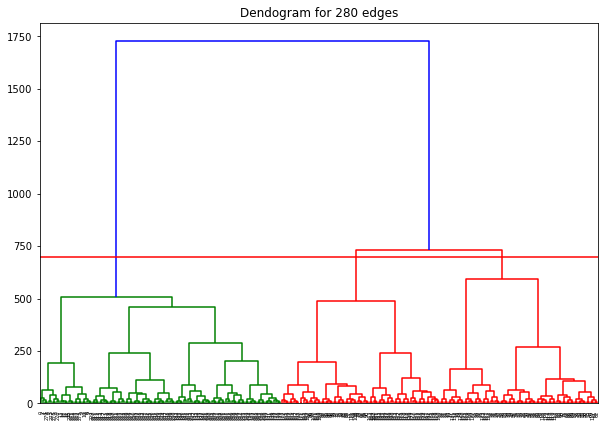

```
Graph with 1000 edges.
Groupe 1: [1, 16, 18, 20, 21, 23, 24, 25, 28, 29, 30, 31, 32, 34, 40, 41, 42, 43, 44, 45, 47, 49, 50, 51, 52, 57, 59, 62, 64, 66, 71, 72, 74, 76, 77, 79, 80, 83, 84, 85, 87, 90, 94, 96, 97, 98, 99, 102, 104, 107, 109, 111, 112, 114, 115, 116, 117, 118, 120, 122, 124, 125, 127, 130, 134, 136, 137, 13…
Groupe 2: [7, 8, 10, 13, 14, 15, 17, 22, 26, 27, 33, 37, 38, 39, 48, 56, 60, 63, 69, 75, 81, 82, 91, 93, 95, 101, 103, 105, 108, 113, 123, 128, 129, 131, 132, 146, 147, 157, 160, 161, 168, 175, 177, 188, 189, 191, 194, 198, 201, 203, 206, 212, 214, 215, 216, 218, 222, 223, 224, 225, 230, 231, 232, 2…
Groupe 3: [2, 3, 4, 5, 6, 9, 11, 12, 19, 35, 36, 46, 53, 54, 55, 58, 61, 65, 67, 68, 70, 73, 78, 86, 88, 89, 92, 100, 106, 110, 119, 121, 126, 133, 135, 144, 148, 151, 156, 159, 165, 167, 171, 173, 176, 181, 185, 187, 211, 220, 221, 233, 234, 239, 242, 244, 251, 252, 254, 258, 261, 271, 272, 288, 28…
```

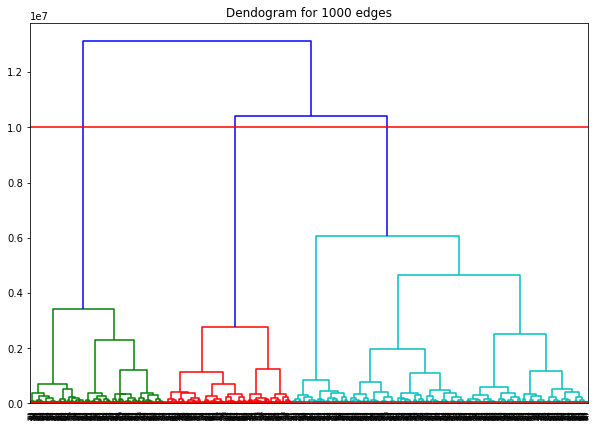

```
Graph with 4461 edges.
Groupe 1: [1, 2, 3, 4, 5, 6, 7, 8, 9, 10, 11, 12, 13, 14, 15, 16, 17, 18, 19, 20, 21, 22, 23, 24, 25, 26, 27, 28, 29, 30, 31, 32, 33, 34, 35, 36, 37, 38, 39, 40, 41, 42, 43, 44, 45, 46, 47, 48, 49, 50, 51, 52, 53, 54, 55, 56, 57, 58, 59, 60, 61, 62, 63, 64, 65, 66, 67, 68, 69, 70, 71, 72, 73, 74, 75…
Groupe 2: [229, 259, 261, 277, 282, 287, 304, 318, 324, 327, 333, 336, 344, 349, 354, 358, 359, 362, 363, 365, 380, 383, 384, 386, 387, 400, 403, 405, 406, 408, 409, 414, 415, 418, 424, 429, 431, 432, 434, 438, 441, 443, 444, 445, 452, 453, 455, 458, 461, 463, 464, 465, 466, 468, 469, 474, 481, 482,…
Groupe 3: [2097, 2110, 2140, 2171, 2172, 2184, 2185, 2190, 2194, 2230, 2234, 2276, 2281, 2285, 2298, 2307, 2315, 2325, 2331, 2338, 2352, 2357, 2376, 2387, 2393, 2396, 2409, 2413, 2422, 2434, 2452, 2454, 2469, 2473, 2478, 2482, 2492, 2503, 2507, 2523, 2525, 2526, 2541, 2545, 2547, 2558, 2582, 2589, 2…
```

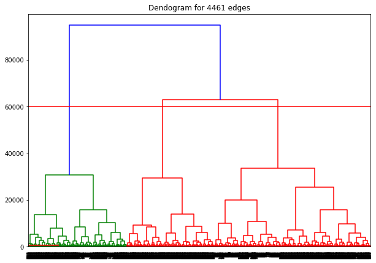

```python
import matplotlib.pyplot as plt
from sklearn.cluster import AgglomerativeClustering
from scipy.cluster.hierarchy import dendrogram, linkage
import numpy as np
import csv


class Cha:
    def __init__(self, path):
        # open file to initialize the graph
        self.file_to_read = csv.reader(open(path, 'r'), delimiter=' ')
        self.graph = {}
        self.name = []
        self._id = []

    def read_file(self):
        """
        Read file and store nodes
        :return: np.array with 2 coordinates for each node
        """
        for coor in self.file_to_read:
            filter_coor = list(filter(None, coor))  # remove empty content
            try:
                node = int(filter_coor[0])
                coord1 = float(filter_coor[1])
                coord2 = float(filter_coor[2])
                try:
                    sommet
                    sommet = np.append(sommet, [[coord1, coord2]], axis=0)
                except Exception:
                    sommet = np.array([[coord1, coord2]])
                self.name.append(node)
            except Exception:
                pass
        print('Graph with {} edges.'.format(sommet.shape[0]))
        return sommet

    def cha(self, sommet):
        """
        Function to create 3 clusters using the euclidean distance
        :param sommet: np array with nodes coordinates
        :return: list of nodes in each group
        """
        clustering = AgglomerativeClustering(n_clusters=3, affinity='euclidean', linkage='ward').fit(sommet)
        print('Groupe 1: {}'.format([self.name[idx] for idx, i in enumerate(clustering.labels_) if i == 0]))
        print('Groupe 2: {}'.format([self.name[idx] for idx, i in enumerate(clustering.labels_) if i == 1]))
        print('Groupe 3: {}'.format([self.name[idx] for idx, i in enumerate(clustering.labels_) if i == 2]))
        #plt.figure()
        #plt.scatter(sommet[:, 0], sommet[:, 1], c=clustering.labels_, cmap='rainbow')
        #plt.show()
        #print(clustering.labels_)

    def scip(self, sommet):
        """
        Plot dendogram
        :param sommet: np array with nodes coordinates
        :return: plot
        """
        plt.figure(figsize=(10, 7))
        plt.title("Dendogram for {} edges".format(sommet.shape[0]))
        dendrogram(linkage(sommet, method='ward'))
        plt.hlines(y=700, xmin=0, xmax=4000, colors='r')
        plt.hlines(y=10000000, xmin=0, xmax=20000, colors='r')
        plt.hlines(y=60000, xmin=0, xmax=200000, colors='r')
        plt.show()

    def main(self):
        sommets = self.read_file()
        self.cha(sommets)
        self.scip(sommets)


if __name__ == '__main__':
    cha = Cha('a280.tsp.txt')
    cha.main()
    cha = Cha('dsj1000.tsp.txt')
    cha.main()
    cha = Cha('fnl4461.tsp.txt')
    cha.main()
    # cha = Cha('pla85900.tsp.txt')
    # cha.main()
```